# Reguły asocjacyjne w R

2022-02-21

## Wstęp

Dane dotyczą transakcji, a każda transakcja dotyczy zbioru produktów. Chcemy wyznaczyć produkty często kupowane razem.

Oznaczmy przez `P` zbiór produktów `P = {P1, P2, ..., Pn}`. **Regułą asocjacyjną** nazwiemy parę `L→R`, przy czym `L`,`R` to podzbiory zbioru `P`. Ktoś kto kupił kiełbasę kupił także musztardę i ketchup (`kiełbasa → {musztarda,ketchup}`.) Prościej się nie da:-)

Reguł postaci `L→R` można wygenerować dowolnie wiele, ale nie każde są użyteczne. Potrzebne są kryteria użyteczności.

**Support** (wsparcie) określa jak często zdarza się reguła `LR`. To iloraz liczby transakcji zawierających regułę `LR` do liczby wszystkich transakcji. Jeżeli transakcji `kiełbasa → {mleko sojowe}` jest bardzo mało, to nie mają one większego praktycznego znaczenia (przypadek)

**Confidence** (wiarygodność), czyli procent `LR/L` czyli ile transakcji kupna kiełbasy skończyło się kupnem musztardy i ketchupu. Oczywiście interesują nas reguły o dużej wiarygodności. Jeżeli w analizowanym zbiorze transakcji było 2000 zawierających kiełbasę oraz 1500 kiełbasę, musztardę i ketchup to wiarygodność reguły (`kiełbasa → {musztarda,ketchup}` wynosi 75%.

**Lift** (podniesienie), wsparcie `LR` do iloczynu wsparcia `L` oraz `R` (iloczyn wspracia `L` oraz `R` odpowiada sytuacji gdy `L`/`R` są niezależne); Jeżeli lift =1 to nie ma związku między `L` i `R`; jeżeli lift > 1 to `L` zwiększa szanse na `R`; jeżeli lift < 1 to `L` zmniejsza szanse na `R`.

## Przykład

Baza danych `mbo.db` zawiera *toy example* hurtowni danych składającej się dokładnie z 4 tabel. Tabela `TRANS` to tabela faktów (pozycje z paragonów); tabele `SHOP`, `PROD`, `DATE` to wymiary:

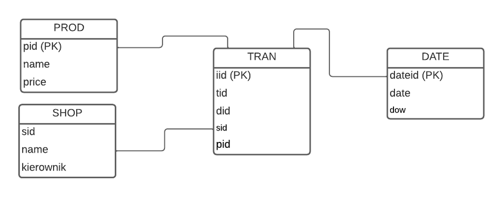

Baza dla utrudnienia jest w formacie `SQLite`. Należy dane wydobyć i złączyć. Konkretnie do danych z tablicy `TRANS` (`iid` oraz `tid` – identyfikator paragonu) dodać nazwy produktów (`name`) żeby całość była bardziej czytelna. Tutaj od razu do akcji wkracza język programowania R. Korzystamy z dwóch bibliotek `arules` do wyznaczania reguł asocjacyjnych oraz `RSQLite` do komunikowania się z SQLite:

```r
library("arules")
library(RSQLite)

## Łączenie się z bazą z pliku mbo.db
myDB <- "mbo.db"
conn <- dbConnect(drv = SQLite(), dbname= myDB)

## lista sklepów na rozgrzewkę
## shops <- dbGetQuery(conn, "SELECT *  FROM shop")

## lista pozycji (złączenie tablei TRANS z PROD)
items <- dbGetQuery(conn, "SELECT iid, tid, name  FROM tran
                    inner join prod on tran.pid=prod.pid")

## zamykamy bazę
dbDisconnect(conn)
```

W tym momencie ramka `items` zawiera dane niezbędne do analizy:

```r
translist <- split (items$name, items$tid, "transactions")
rul <- apriori(translist, parameter = list(support=0.005,
                                           confidence=0.5, maxlen=10, minlen=2))
```

```
## Apriori
##
## Parameter specification:
##  confidence minval smax arem  aval originalSupport maxtime support minlen
##         0.5    0.1    1 none FALSE            TRUE       5   0.005      2
##  maxlen target  ext
##      10  rules TRUE
##
## Algorithmic control:
##  filter tree heap memopt load sort verbose
##     0.1 TRUE TRUE  FALSE TRUE    2    TRUE
##
## Absolute minimum support count: 37
##
## set item appearances ...[0 item(s)] done [0.00s].
## set transactions ...[120 item(s), 7501 transaction(s)] done [0.00s].
## sorting and recoding items ... [101 item(s)] done [0.00s].
## creating transaction tree ... done [0.00s].
## checking subsets of size 1 2 3 4 done [0.00s].
## writing ... [20 rule(s)] done [0.00s].
## creating S4 object  ... done [0.00s].
```

```r
inspect(rul)
```

```
##      lhs                                 rhs             support     confidence
## [1]  {salmon, spaghetti}              => {mineral water} 0.006799093 0.5049505
## [2]  {olive oil, soup}                => {mineral water} 0.005199307 0.5820896
## [3]  {frozen vegetables, soup}        => {mineral water} 0.005065991 0.6333333
## [4]  {ground beef, soup}              => {mineral water} 0.005065991 0.5205479
## [5]  {milk, soup}                     => {mineral water} 0.008532196 0.5614035
## [6]  {chocolate, soup}                => {mineral water} 0.005599253 0.5526316
## [7]  {soup, spaghetti}                => {mineral water} 0.007465671 0.5233645
## [8]  {cooking oil, eggs}              => {mineral water} 0.006399147 0.5454545
## [9]  {milk, turkey}                   => {mineral water} 0.006132516 0.5411765
## [10] {chicken, chocolate}             => {mineral water} 0.007598987 0.5181818
## [11] {frozen vegetables, olive oil}   => {spaghetti}     0.005732569 0.5058824
## [12] {frozen vegetables, olive oil}   => {mineral water} 0.006532462 0.5764706
## [13] {milk, olive oil}                => {mineral water} 0.008532196 0.5000000
## [14] {chocolate, olive oil}           => {mineral water} 0.008265565 0.5040650
```

[output cut: 27 more lines]

albo ładniej:

```r
bjuty_rules <- DATAFRAME(rul)
library("knitr")
kable(bjuty_rules, col.names = c('L', 'R', 'wsparcie', 'wiarygodność', 'coverage',
                                 'lift', 'n'))
```

| L | R | wsparcie | wiarygodność | coverage | lift | n |
| --- | --- | --- | --- | --- | --- | --- |
| {salmon,spaghetti} | {mineral water} | 0.0067991 | 0.5049505 | 0.0134649 | 2.118363 | 51 |
| {olive oil,soup} | {mineral water} | 0.0051993 | 0.5820896 | 0.0089321 | 2.441976 | 39 |
| {frozen vegetables,soup} | {mineral water} | 0.0050660 | 0.6333333 | 0.0079989 | 2.656954 | 38 |
| {ground beef,soup} | {mineral water} | 0.0050660 | 0.5205479 | 0.0097320 | 2.183798 | 38 |
| {milk,soup} | {mineral water} | 0.0085322 | 0.5614035 | 0.0151980 | 2.355195 | 64 |
| {chocolate,soup} | {mineral water} | 0.0055993 | 0.5526316 | 0.0101320 | 2.318395 | 42 |
| {soup,spaghetti} | {mineral water} | 0.0074657 | 0.5233645 | 0.0142648 | 2.195613 | 56 |
| {cooking oil,eggs} | {mineral water} | 0.0063991 | 0.5454545 | 0.0117318 | 2.288286 | 48 |
| {milk,turkey} | {mineral water} | 0.0061325 | 0.5411765 | 0.0113318 | 2.270338 | 46 |
| {chicken,chocolate} | {mineral water} | 0.0075990 | 0.5181818 | 0.0146647 | 2.173871 | 57 |
| {frozen vegetables,olive oil} | {spaghetti} | 0.0057326 | 0.5058824 | 0.0113318 | 2.905531 | 43 |
| {frozen vegetables,olive oil} | {mineral water} | 0.0065325 | 0.5764706 | 0.0113318 | 2.418404 | 49 |
| {milk,olive oil} | {mineral water} | 0.0085322 | 0.5000000 | 0.0170644 | 2.097595 | 64 |
| {chocolate,olive oil} | {mineral water} | 0.0082656 | 0.5040650 | 0.0163978 | 2.114649 | 62 |
| {ground beef,shrimp} | {spaghetti} | 0.0059992 | 0.5232558 | 0.0114651 | 3.005315 | 45 |
| {ground beef,pancakes} | {mineral water} | 0.0074657 | 0.5137615 | 0.0145314 | 2.155327 | 56 |
| {frozen vegetables,ground beef} | {spaghetti} | 0.0086655 | 0.5118110 | 0.0169311 | 2.939582 | 65 |
| {frozen vegetables,ground beef} | {mineral water} | 0.0091988 | 0.5433071 | 0.0169311 | 2.279276 | 69 |
| {ground beef,milk} | {mineral water} | 0.0110652 | 0.5030303 | 0.0219971 | 2.110308 | 83 |
| {eggs,ground beef} | {mineral water} | 0.0101320 | 0.5066667 | 0.0199973 | 2.125563 | 76 |

koniec analizy…